# Predicting IPL first-innings totals before play

# 1 Objective (Problem)

Can we predict a team’s first-innings total in the IPL after the toss and announced playing XIs, but before any delivery is bowled? A useful estimate would help analysts judge likely scoring conditions and help fans distinguish an unusually good innings from one that is typical for its context. The target is the actual total, including extras and shortened innings; it is not a hypothetical full-length score.

The research questions are:

- Does a pre-innings model improve on the historical training mean and earlier venue average?
- Do player-strength features and season context add useful information beyond venue alone?
- Can PCA, factor analysis and venue groups simplify the inputs while preserving predictive value?
- How sensitive are conclusions to influential innings and unequal error variance?

**Success:** beat both baselines on the reserved final season, with honest error and interval reporting. Winning a statistical comparison is not guaranteed. Win probability, live-innings forecasts, weather forecasting and causal player valuation are outside this study.

# 2 Data description (overview)

The primary source is [Cricsheet’s IPL Ashwin CSV archive](https://cricsheet.org/downloads/). Its [format documentation](https://cricsheet.org/format/csv_ashwin/) explains the delivery and match-info files. The companion [JSON format](https://cricsheet.org/format/json/) supplies substitution records for reconstructing initial XIs and final-stage markers for season completion; delivery targets remain based on CSV.

One row represents one observed first innings. After burn-in and identity checks, the study contains 1185 innings spanning 2009–2026. The outcome is the sum of bat runs and extras. Realised wickets, legal balls, shortened status and result method support cleaning or diagnostics and never enter the pre-innings predictor pool.

## 2.1 Variable dictionary

```r
tab("variable_dictionary")
```

| name | description | type | units | construction | known_before_innings |
| --- | --- | --- | --- | --- | --- |
| venue_avg_first_inn | Earlier venue mean first-innings total | numeric | runs | Mean of earlier-date first-innings totals at this venue; earlier league mean if none | yes |
| venue_sd_first_inn | Earlier venue standard deviation | numeric | runs | Sample SD of earlier-date venue totals; earlier league SD if fewer than two | yes |
| venue_prior_matches | Number of earlier venue innings | numeric | innings | Count of first innings played at this venue on earlier dates | yes |
| venue_boundary_rate | Earlier venue boundary-delivery share | numeric | proportion | Mean earlier venue innings boundary-delivery fraction, including all delivery events; earlier league fallback | yes |
| season_index | Calendar season position | numeric | index | Calendar season year minus the earliest source year, plus the index offset | yes |
| toss_winner_batting_first | Toss winner is batting first | numeric | binary | Binary indicator that the toss winner is the team batting first, checked against toss decision | yes |
| bat_average | XI mean career batting average | numeric | runs/dismissal | XI mean of player bat runs divided by at least one dismissal; sparse histories blend with earlier league rates | yes |
| bat_strike_rate | XI mean career strike rate | numeric | runs/100 balls | XI mean of player bat runs per hundred faced balls; wides excluded from faced balls | yes |
| bat_boundary_pct | XI mean career boundary percentage | numeric | percent | XI mean of actual boundary events per hundred faced balls; running fours excluded | yes |
| bat_top_order_sr | Strike rate of three XI players with earliest historical batting positions | numeric | runs/100 balls | Mean strike rate of the three XI players with earliest historical mean batting positions; registry IDs break ties | yes |
| bat_depth | XI count with historical strike rate above threshold | numeric | players | Count of XI players whose earlier shrunken career strike rate exceeds the saved depth threshold | yes |
| team_last10_total | Team mean of most recent historical first innings | numeric | runs | Mean of the team’s most recent earlier first innings, up to the saved history window; league fallback | yes |
| bowl_economy | Opposition XI mean economy | numeric | runs/over | Opposition XI mean charged runs per over of legal balls; byes, leg-byes and penalties excluded | yes |
| bowl_strike_rate | Opposition XI mean bowling strike rate | numeric | balls/wicket | Opposition XI mean legal balls divided by at least one bowler-credited wicket | yes |
| bowl_dot_pct | Opposition XI mean dot percentage | numeric | percent | Opposition XI mean percent of legal deliveries conceding no total runs | yes |
| bowl_wickets_match | Opposition XI mean wickets per bowling appearance | numeric | wickets/appearance | Opposition XI mean credited wickets per match with a bowling appearance, rather than per XI selection | yes |
| bowl_death_economy | Opposition XI mean death-over economy | numeric | runs/over | Opposition XI mean charged runs per over in the final scheduled overs; sparse death-ball history blends with league rate | yes |

“Known before innings” applies to the predictors above. The target and diagnostic outcome flags are unavailable at prediction time. Batting and bowling rates use IPL history rather than all-format international careers. A player’s wicketless or dismissal-free history needs finite denominators; these conventions are documented in D-006.

## 2.2 Cleaning and missing information

```r
tab("data_quality")
```

| item | value |
| --- | --- |
| info files | 1243 |
| raw deliveries | 295732 |
| super-over deliveries removed | 175 |
| first innings | 1243 |
| no-result first innings | 9 |
| D/L first innings | 23 |
| curtailed first innings | 28 |
| unverified initial XI | 0 |
| missing player registry IDs | 0 |
| date start | 2008-04-18 |
| date end | 2026-05-31 |
| seasons | 19 |

```r
tab("feature_quality")
```

| item | value |
| --- | --- |
| burn-in innings | 58 |
| unverified XI after burn-in | 0 |
| incomplete-season innings | 0 |
| nonpositive totals | 0 |
| modelled innings | 1185 |
| numeric predictors | 17 |
| seed | 42 |
| shrinkage balls | 20 |
| depth strike-rate threshold | 125 |
| leakage audit rows | 20 |

```r
tab("missing_values")
```

| variable | missing_values |
| --- | --- |
| match_id | 0 |
| date | 0 |
| season | 0 |
| venue | 0 |
| toss_winner | 0 |
| toss_decision | 0 |
| no_result | 0 |
| dl | 0 |
| final | 0 |
| xi_verified | 0 |
| innings | 0 |
| batting_team | 0 |
| bowling_team | 0 |
| first_innings_total | 0 |
| legal_balls | 0 |
| wickets | 0 |
| boundary_rate | 0 |
| curtailed | 0 |
| log_total | 0 |
| venue_avg_first_inn | 0 |
| venue_sd_first_inn | 0 |
| venue_prior_matches | 0 |
| venue_boundary_rate | 0 |
| season_index | 0 |
| toss_winner_batting_first | 0 |
| bat_average | 0 |
| bat_strike_rate | 0 |
| bat_boundary_pct | 0 |
| bat_top_order_sr | 0 |
| bat_depth | 0 |
| team_last10_total | 0 |
| bowl_economy | 0 |
| bowl_strike_rate | 0 |
| bowl_dot_pct | 0 |
| bowl_wickets_match | 0 |
| bowl_death_economy | 0 |
| split | 0 |

```r
tab("season_completeness")
```

| season | matches | has_final |
| --- | --- | --- |
| 2008 | 58 | TRUE |
| 2009 | 57 | TRUE |
| 2010 | 60 | TRUE |
| 2011 | 73 | TRUE |
| 2012 | 74 | TRUE |
| 2013 | 76 | TRUE |
| 2014 | 60 | TRUE |
| 2015 | 59 | TRUE |
| 2016 | 60 | TRUE |
| 2017 | 59 | TRUE |
| 2018 | 60 | TRUE |
| 2019 | 60 | TRUE |
| 2020 | 60 | TRUE |
| 2021 | 60 | TRUE |
| 2022 | 74 | TRUE |
| 2023 | 74 | TRUE |
| 2024 | 71 | TRUE |
| 2025 | 74 | TRUE |
| 2026 | 74 | TRUE |

Names are reconciled with reference tables. Super overs are removed; no-result and D/L first innings with observable deliveries remain in the historical data. Matches without a verified original XI cannot enter the modelling sample. Missing historical player information uses earlier league rates, and a venue without earlier innings uses earlier league context. Predictor finiteness is checked before fitting.

## 2.3 Predictor ratio and evaluation timeline

The limit counts each dummy, component, factor score and added term as a predictor. The entire proposed candidate pool must pass before selection starts.

```r
tab("ratio_summary")
```

| label | fits_checked | minimum_N | maximum_p | all_pass |
| --- | --- | --- | --- | --- |
| candidate pool including interaction and polynomial | 1 | 1037 | 19 | TRUE |
| Exclude Cook-influential training innings | 1 | 983 | 17 | TRUE |
| Exclude shortened training innings | 1 | 1018 | 17 | TRUE |
| Factor-score regression | 1 | 1037 | 9 | TRUE |
| Full multiple regression | 1 | 1037 | 17 | TRUE |
| Group-variance weighted least squares | 1 | 1037 | 17 | TRUE |
| Interaction candidate | 1 | 1037 | 18 | TRUE |
| lm internal: first_innings_total ~ venue_avg_first_inn | 1 | 1037 | 1 | TRUE |
| lm internal: first_innings_total ~ venue_avg_first_inn + venue_boundary_rate + season_index + bat_average + bat_strike_rate + bat_depth | 2 | 1037 | 6 | TRUE |
| lm internal: first_innings_total ~ venue_avg_first_inn + venue_boundary_rate + season_index + bat_average + bat_strike_rate + bat_depth + bowl_economy | 2 | 1037 | 7 | TRUE |
| lm internal: first_innings_total ~ venue_avg_first_inn + venue_boundary_rate + season_index + bat_average + bat_strike_rate + bat_depth + team_last10_total + bowl_economy | 2 | 1037 | 8 | TRUE |
| lm internal: first_innings_total ~ venue_avg_first_inn + venue_boundary_rate + season_index + bat_average + bat_strike_rate + bat_depth + team_last10_total + bowl_economy + bowl_dot_pct | 2 | 1037 | 9 | TRUE |
| lm internal: first_innings_total ~ venue_avg_first_inn + venue_boundary_rate + season_index + bat_average + bat_strike_rate + bat_depth + venue_cluster | 1 | 1037 | 7 | TRUE |
| lm internal: first_innings_total ~ venue_avg_first_inn + venue_boundary_rate + season_index + toss_winner_batting_first + bat_average + bat_strike_rate + bat_depth + team_last10_total + bowl_economy +… | 2 | 1037 | 10 | TRUE |
| lm internal: first_innings_total ~ venue_avg_first_inn + venue_prior_matches + venue_boundary_rate + season_index + toss_winner_batting_first + bat_average + bat_strike_rate + bat_boundary_pct + bat_d… | 2 | 1037 | 12 | TRUE |
| lm internal: first_innings_total ~ venue_avg_first_inn + venue_prior_matches + venue_boundary_rate + season_index + toss_winner_batting_first + bat_average + bat_strike_rate + bat_boundary_pct + bat_d… | 2 | 1037 | 13 | TRUE |
| lm internal: first_innings_total ~ venue_avg_first_inn + venue_prior_matches + venue_boundary_rate + season_index + toss_winner_batting_first + bat_average + bat_strike_rate + bat_boundary_pct + bat_d… | 2 | 1037 | 14 | TRUE |
| lm internal: first_innings_total ~ venue_avg_first_inn + venue_prior_matches + venue_boundary_rate + season_index + toss_winner_batting_first + bat_average + bat_strike_rate + bat_boundary_pct + bat_t… | 2 | 1037 | 15 | TRUE |
| lm internal: first_innings_total ~ venue_avg_first_inn + venue_prior_matches + venue_boundary_rate + season_index + toss_winner_batting_first + bat_average + bat_strike_rate + bat_depth + team_last10_… | 2 | 1037 | 11 | TRUE |
| lm internal: first_innings_total ~ venue_avg_first_inn + venue_sd_first_inn + venue_prior_matches + venue_boundary_rate + season_index + toss_winner_batting_first + bat_average + bat_strike_rate + bat… | 2 | 1037 | 16 | TRUE |
| lm internal: first_innings_total ~ venue_avg_first_inn + venue_sd_first_inn + venue_prior_matches + venue_boundary_rate + season_index + toss_winner_batting_first + bat_average + bat_strike_rate + bat… | 4 | 983 | 17 | TRUE |
| lm internal: first_innings_total ~ venue_avg_first_inn + venue_sd_first_inn + venue_prior_matches + venue_boundary_rate + season_index + toss_winner_batting_first + bat_average + bat_strike_rate + bat… | 1 | 1037 | 18 | TRUE |
| lm internal: first_innings_total ~ venue_avg_first_inn + venue_sd_first_inn + venue_prior_matches + venue_boundary_rate + season_index + toss_winner_batting_first + bat_average + bat_strike_rate + bat… | 1 | 1037 | 18 | TRUE |
| lm internal: first_innings_total ~ venue_avg_first_inn + venue_sd_first_inn + venue_prior_matches + venue_boundary_rate + season_index + toss_winner_batting_first + FA1 + FA2 + FA3 | 1 | 1037 | 9 | TRUE |
| lm internal: first_innings_total ~ venue_avg_first_inn + venue_sd_first_inn + venue_prior_matches + venue_boundary_rate + season_index + toss_winner_batting_first + PCA1 + PCA2 + PCA3 | 1 | 1037 | 9 | TRUE |
| lm internal: log_total ~ venue_avg_first_inn + venue_sd_first_inn + venue_prior_matches + venue_boundary_rate + season_index + toss_winner_batting_first + bat_average + bat_strike_rate + bat_boundary_… | 1 | 1037 | 17 | TRUE |
| Log total GQ internal OLS segment 1 | 1 | 518 | 17 | TRUE |
| Log total GQ internal OLS segment 2 | 1 | 519 | 17 | TRUE |
| Log-total regression | 1 | 1037 | 17 | TRUE |
| Multiple regression with venue groups | 1 | 1037 | 7 | TRUE |
| PCA-score regression | 1 | 1037 | 9 | TRUE |
| Polynomial candidate | 1 | 1037 | 18 | TRUE |
| Raw GQ internal OLS segment 1 | 1 | 518 | 17 | TRUE |
| Raw GQ internal OLS segment 2 | 1 | 519 | 17 | TRUE |
| Simple regression | 1 | 1037 | 1 | TRUE |

```r
tab("split_summary")
```

| split | N | first_season | last_season |
| --- | --- | --- | --- |
| test | 74 | 2026 | 2026 |
| train | 1037 | 2009 | 2024 |
| validation | 74 | 2025 | 2025 |

```r
tab("leakage_audit")
```

| check | rows | pass |
| --- | --- | --- |
| strict earlier-date brute-force reconstruction | 20 | TRUE |

```r
show_figures(1)
```

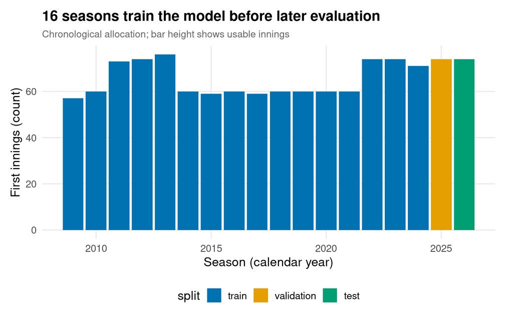

**How to read this:** Read from left to right; colour marks each split.

**What it means:** Later seasons test how well earlier evidence transfers.

## 2.4 Exploratory overview

Outcome plots use training data. The test season was evaluated in the earlier project; this course-aligned revision does not select methods using its outcomes.

```r
show_figures(2:4)
```

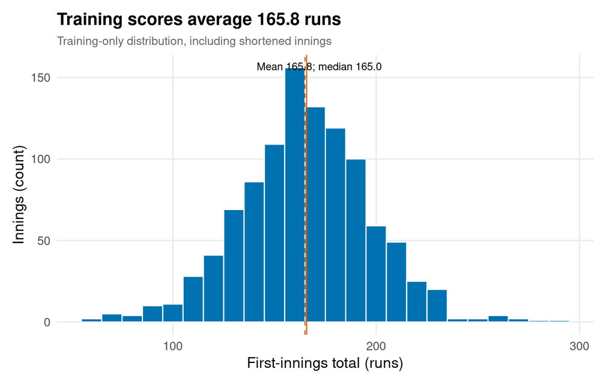

**How to read this:** Bars count scores; solid and dashed lines mark mean and median.

**What it means:** Shortened and unusually strong innings broaden the distribution.

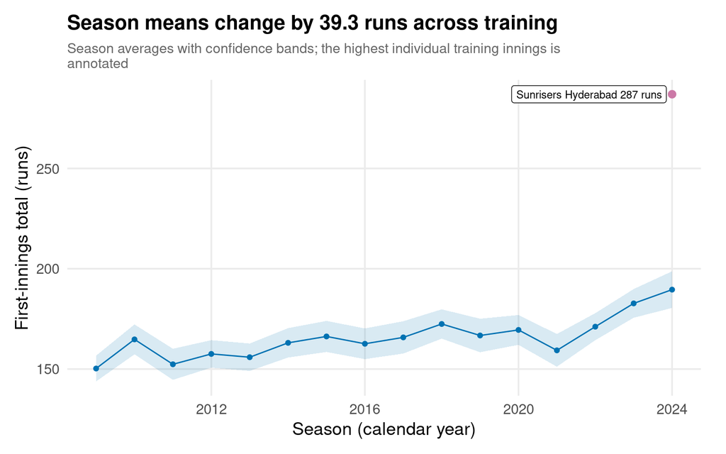

**How to read this:** The ribbon measures uncertainty in each season mean, not individual scores.

**What it means:** Changing scoring conditions motivate a time predictor.

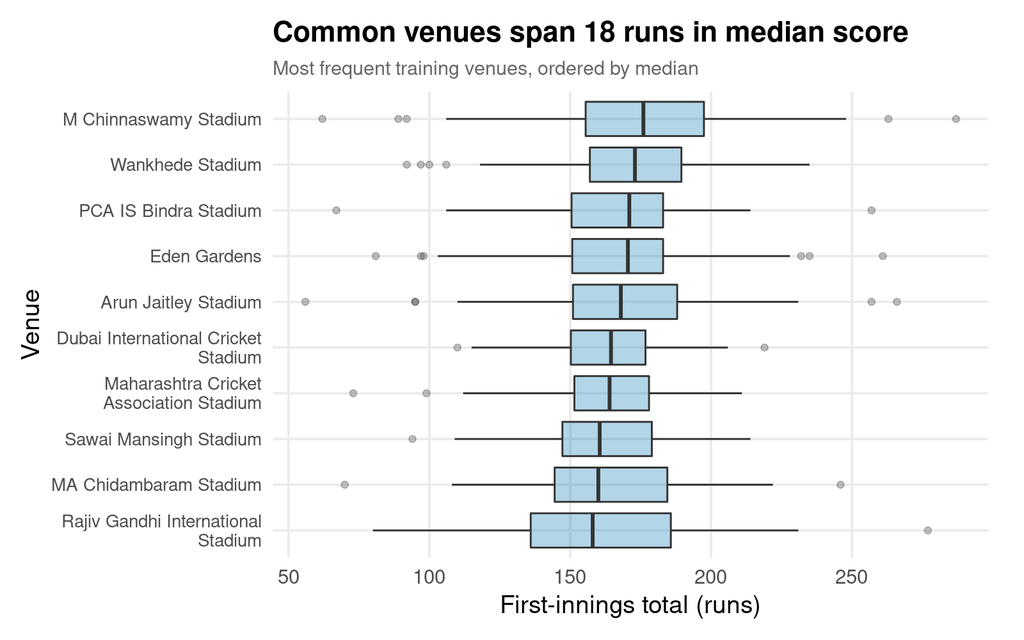

**How to read this:** The box spans the middle half of scores; the central line is the median.

**What it means:** Venue differences are useful but their score distributions overlap.

# 3 Methods used

## 3.1 Introduction to R pipeline

R imports delivery and match records, fixes identities and aggregates deliveries into innings. The verified preparation pipeline remains unchanged, while statistical scripts now use explicit class-style assignments and model calls. Each historical feature uses strictly earlier dates. The target is $Y=\sum_b(\text{bat runs}_b+\text{extras}_b)$. The course-alignment table maps every analysis to its supplied example; D-018 records the student-approved scope.

```r
tab("course_alignment")
```

| topic | method | source |
| --- | --- | --- |
| Introduction to R | Import, inspect, summaries, covariance and correlation | ../Predictive Modelling/Intro to R/Introductory R and graphics (2).R |
| Simple Regression | lm, summary, confint, predict and residual diagnostics | ../Predictive Modelling/Multiple Regression/Boston data analysis.txt |
| Multiple Regression | Multiple lm, backward step / stepAIC, squared terms and anova | ../Predictive Modelling/Multiple Regression/Store24.R |
| PCA | Parallel analysis, principal scores and prcomp comparison | ../Predictive Modelling/PCA/PCA class.R |
| Factor Analysis | Principal-axis fa with no rotation and varimax | ../Predictive Modelling/FA/FA.R |
| Cluster Analysis | Scale, Euclidean distance and average-linkage clustering | ../Predictive Modelling/Cluster Analysis/CA.R |
| Cluster Analysis | Complete linkage, k-means, elbow and silhouette | ../Predictive Modelling/Cluster Analysis/cluster analysis.txt |
| Cluster Analysis | Single linkage, cutree, centres and membership tables | ../Predictive Modelling/Cluster Analysis/Cluster Analysis Utilities example.R |
| Outlier Detection | Studentized residuals, leverage, Cook, DFFITS and DFBETAS | ../Predictive Modelling/Outliers/outliers.R |
| Outlier Detection | Mahalanobis distance with covariance adjustment | ../Predictive Modelling/Cluster Analysis/Cluster Analysis.pdf |
| Heteroscedasticity | Goldfeld–Quandt, log response and group-variance WLS | ../Predictive Modelling/Heteroscedasticity/Heteroskedasticity.R |

## 3.2 Simple regression

The Boston example starts with `lm()`, `summary()`, `confint()` and `predict()`. We follow that pattern to estimate the average score associated with an earlier venue mean, then inspect fitted values and residuals. The slope describes association, not the causal effect of moving a match. The model is $Y_i=\beta_0+\beta_1V_i+\epsilon_i$, fitted by minimising squared residuals; see D-019.

## 3.3 Multiple regression

The Store24 and Boston examples extend the formula to several predictors, select backward with AIC, and compare added terms using `anova()`. We fit all historical inputs, compare the full and selected models, and investigate one interaction and one squared term against the full fit so their main effects remain present. Correlations and changes in coefficients explain overlapping information. The model is $Y_i=\beta_0+\sum_j\beta_jX_{ij}+\epsilon_i$; subsequent significance statements are exploratory because selection also used the data.

## 3.4 PCA

PCA summarises correlated numerical inputs through directions of variation. We follow `PCA class.R` with parallel analysis and unrotated `psych::principal()` scores, verified against the demonstrated `prcomp()` approach. Training means, standard deviations and score weights remain fixed when transforming later matches. Explained input variance describes compression rather than forecasting accuracy; D-020 records the settings.

For feature $j$, standardise $x_{ij}$ using the training mean $\mu_j$ and standard deviation $s_j$:

$$z_{ij}=\frac{x_{ij}-\mu_j}{s_j},\qquad R=\frac{Z^\mathsf{T}Z}{N-1}.$$

$Z$ has training matches in rows and strength features in columns; $R$ is their correlation matrix. Eigenvectors $v_k$ and eigenvalues $\lambda_k$ satisfy $Rv_k=\lambda_kv_k$. A raw component score is $Zv_k$, with variance $\lambda_k$. The class function returns unit-variance scores:

$$PC_{ik}=\sum_j z_{ij}\frac{v_{jk}}{\sqrt{\lambda_k}}.$$

Its loading is $v_{jk}\sqrt{\lambda_k}$, while its score weight is $v_{jk}/\sqrt{\lambda_k}$: these are different quantities. We regress total on retained component scores and context:

$$\widehat Y_i=\widehat\beta_0+\sum_c\widehat\beta_c C_{ic}+\sum_k\widehat\gamma_k PC_{ik}.$$

$C_{ic}$ is context input $c$; $\gamma_k$ is the fitted effect of component score $k$.

## 3.5 Factor Analysis

The supplied `FA.R` uses principal-axis extraction with unrotated and varimax solutions. We follow it to model shared strength variation while retaining feature-specific uniqueness. Parallel analysis and an estimable factor count determine the training dimension; held-out factor scores use the saved training weights. Negative uniqueness is an improper solution and is reported explicitly, rather than interpreted as a physical ability.

For a vector of standardised inputs $z_i$, the orthogonal factor model is:

$$z_i=L f_i+u_i,\qquad \mathrm{Cov}(z_i)\approx LL^\mathsf{T}+\Psi.$$

$L$ contains loadings, $f_i$ represents unobserved common factors, and $u_i$ is feature-specific variation. $\Psi$ is diagonal uniqueness; for feature $j$, communality is $h_j^2=\sum_k L_{jk}^2$, with uniqueness approximately $1-h_j^2$. Varimax changes the orientation to simplify interpretation. Factor scores are estimates computed from the package’s training regression-score weights $W_F$:

$$\widehat F=ZW_F,\qquad
\widehat Y_i=\widehat\alpha_0+\sum_c\widehat\alpha_c C_{ic}+\sum_k\widehat\delta_k\widehat F_{ik}.$$

Estimated scores need not be perfectly uncorrelated even when the latent-factor model is orthogonal. Only the proper combined solution supplies our factor-score regression.

## 3.6 Cluster analysis

The course examples standardise numerical profiles, compute Euclidean distance, and compare hierarchical linkage with k-means. We use training venue mean, spread, boundaries and match count, comparing single, complete and average linkage. Maximum silhouette chooses k over the feasible saved range; the elbow is also displayed and contingency tables compare memberships. K-means minimises $\sum_k\sum_{i\in C_k}\lVert z_i-\mu_k\rVert^2$; here $\mu_k$ is a cluster centre, not a season mean. Later venues use frozen centres and strictly earlier histories; see D-021.

## 3.7 Outlier detection

The outlier scripts distinguish unusual errors, leverage and influence. We compute standardized/studentized residuals, leverage, Cook’s distance, DFFITS and DFBETAS, plus the Mahalanobis distance demonstrated in the clustering notes. Flags prompt inspection; the main dataset retains valid extremes. Labelled sensitivity fits exclude shortened or Cook-influential training cases while assessing exactly the same validation innings. Cook’s distance is $D_i=\sum_j(\widehat Y_j-\widehat Y_{j(-i)})^2/((p+1)\widehat\sigma^2)$; the saved threshold table and D-022 document our references.

## 3.8 Heteroscedasticity

The supplied script examines residuals, runs Goldfeld–Quandt testing, compares log responses and fits weighted least squares. We estimate training residual variance in each frozen venue group using `tapply(..., var)`, then fit `lm(..., weights = ...)`. The weight is $w_i=1/\widehat\sigma^2_{g(i)}$, where $g(i)$ is the venue group; invalid or undersized groups use pooled training variance. Exponentiated log predictions estimate a conditional median. D-023 records this construction; WLS is assessed through its standardized residuals rather than a test that discards its weights.

## 3.9 Evaluation and prediction intervals

The student retained chronological train/validation/test evaluation and RMSE, MAE and predictive R-squared as basic project checks. We choose among fitted regressions using validation RMSE, breaking exact ties by fewer predictors; the mean and venue rules remain benchmarks. The training fit stays frozen before revised test metrics are computed. The test season has already been examined in the earlier implementation, so this revision is not newly untouched evidence; see D-024.

With errors $e_i=Y_i-\widehat Y_i$, $\mathrm{RMSE}=\sqrt{\sum e_i^2/N}$, $\mathrm{MAE}=\sum|e_i|/N$, and predictive $R^2=1-\sum e_i^2/\sum(Y_i-\overline Y)^2$. The Boston script’s `predict(..., interval="prediction")` supplies individual-innings intervals at the saved nominal level. These use the fitted regression’s assumptions; the test measures empirical coverage.

# 4 Results

## 4.1 Exploration

The strongest absolute training-feature correlation is 0.92.

```r
show_figures(5)
```

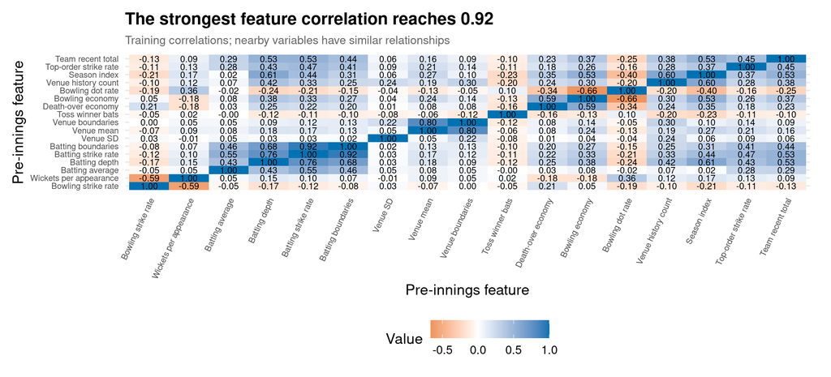

**How to read this:** Colour and printed values show direction and strength.

**What it means:** Correlated measurements can destabilise regression coefficients.

```r
tab("score_summary")
```

| N | mean | median | sd | minimum | maximum |
| --- | --- | --- | --- | --- | --- |
| 1037 | 165.803 | 165 | 31.967 | 56 | 287 |

```r
tab("season_eda")
```

| season | N | mean | se | low | high |
| --- | --- | --- | --- | --- | --- |
| 2009 | 57 | 150.263 | 3.201 | 143.851 | 156.676 |
| 2010 | 60 | 164.783 | 3.719 | 157.341 | 172.225 |
| 2011 | 73 | 152.370 | 3.882 | 144.630 | 160.109 |
| 2012 | 74 | 157.541 | 3.441 | 150.684 | 164.397 |
| 2013 | 76 | 155.895 | 3.426 | 149.070 | 162.720 |
| 2014 | 60 | 163.067 | 3.662 | 155.740 | 170.393 |
| 2015 | 59 | 166.254 | 3.863 | 158.521 | 173.987 |
| 2016 | 60 | 162.600 | 3.822 | 154.953 | 170.247 |
| 2017 | 59 | 165.780 | 4.021 | 157.730 | 173.829 |
| 2018 | 60 | 172.467 | 3.649 | 165.164 | 179.769 |
| 2019 | 60 | 166.733 | 4.172 | 158.384 | 175.082 |
| 2020 | 60 | 169.500 | 3.714 | 162.067 | 176.933 |
| 2021 | 60 | 159.317 | 4.066 | 151.180 | 167.454 |
| 2022 | 74 | 171.122 | 3.377 | 164.392 | 177.852 |
| 2023 | 74 | 182.730 | 3.587 | 175.581 | 189.879 |
| 2024 | 71 | 189.592 | 4.574 | 180.469 | 198.714 |

**How to read this:** season intervals concern estimated averages, while the histogram describes individual scores. **What it means:** time context and overlapping measurements deserve investigation.

## 4.2 Simple regression

An extra run in earlier venue average predicts 0.31 additional runs; training R-squared is 0.008.

```r
show_figures(6:7)
```

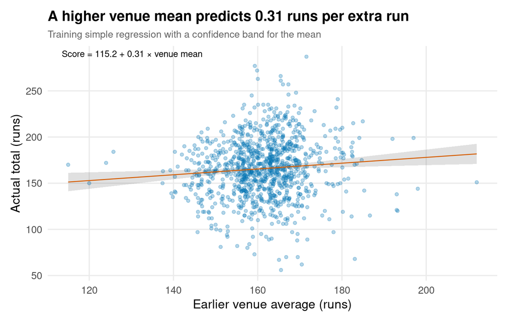

**How to read this:** The line predicts the mean; individual scores scatter around it.

**What it means:** Venue history is an imperfect anchor rather than a precise score forecast.

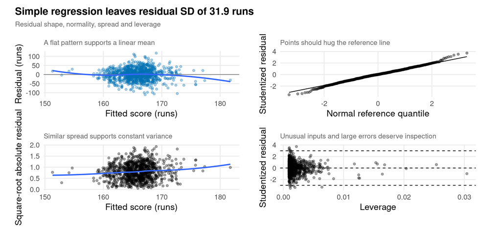

**How to read this:** Each panel’s subtitle describes the desirable pattern.

**What it means:** Diagnostics test whether the model’s assumptions are plausible.

```r
tab("simple_coefficients")
```

| term | estimate | std.error | statistic | p.value | conf.low | conf.high |
| --- | --- | --- | --- | --- | --- | --- |
| (Intercept) | 115.209 | 17.385 | 6.627 | 0.000 | 81.095 | 149.323 |
| venue_avg_first_inn | 0.314 | 0.108 | 2.915 | 0.004 | 0.103 | 0.525 |

```r
tab("simple_summary")
```

| r.squared | adj.r.squared | sigma | statistic | p.value | df | df.residual | nobs |
| --- | --- | --- | --- | --- | --- | --- | --- |
| 0.008 | 0.007 | 31.852 | 8.497 | 0.004 | 1 | 1035 | 1037 |

**How to read this:** the line estimates an average relationship and the panels inspect assumptions. **What it means:** venue history alone leaves considerable individual-score uncertainty.

## 4.3 Multiple regression

Backward AIC retains 6 predictors; the two step functions reach the same specification.

```r
show_figures(8:9)
```

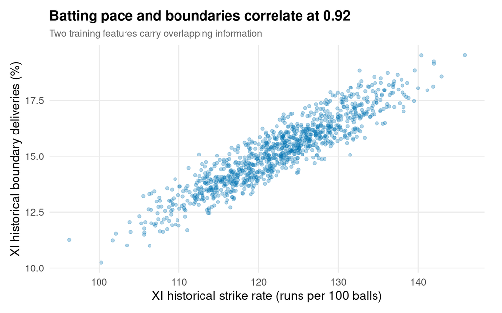

**How to read this:** An upward point cloud shows measurements moving together.

**What it means:** Related inputs can redistribute coefficient estimates when fitted together.

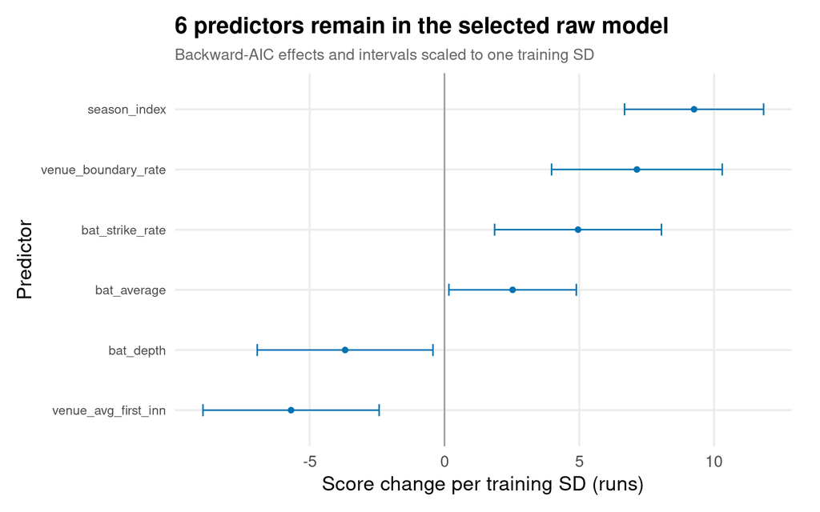

**How to read this:** Intervals crossing zero indicate uncertain conditional effects; the common scale permits comparison.

**What it means:** Each effect holds other included predictors fixed and is not causal; original units remain in the coefficient table.

```r
tab("aic_selection_path")
```

| Step | Df | Deviance | Resid. Df | Resid. Dev | AIC |
| --- | --- | --- | --- | --- | --- |
| NA | NA | NA | 1019 | 934135.3 | 7091.011 |
| - bowl_strike_rate | 1 | 0.000 | 1020 | 934135.3 | 7089.011 |
| - venue_sd_first_inn | 1 | 0.933 | 1021 | 934136.3 | 7087.012 |
| - bat_top_order_sr | 1 | 120.353 | 1022 | 934256.6 | 7085.146 |
| - bowl_wickets_match | 1 | 115.340 | 1023 | 934371.9 | 7083.274 |
| - bowl_death_economy | 1 | 228.362 | 1024 | 934600.3 | 7081.527 |
| - bat_boundary_pct | 1 | 495.771 | 1025 | 935096.1 | 7080.077 |
| - venue_prior_matches | 1 | 1098.956 | 1026 | 936195.0 | 7079.295 |
| - toss_winner_batting_first | 1 | 1501.985 | 1027 | 937697.0 | 7078.957 |
| - bowl_dot_pct | 1 | 1569.718 | 1028 | 939266.7 | 7078.692 |
| - team_last10_total | 1 | 1585.833 | 1029 | 940852.6 | 7078.441 |
| - bowl_economy | 1 | 1615.124 | 1030 | 942467.7 | 7078.220 |

```r
tab("multiple_coefficients")
```

| term | estimate | std.error | statistic | p.value | conf.low | conf.high |
| --- | --- | --- | --- | --- | --- | --- |
| (Intercept) | 87.244 | 26.989 | 3.233 | 0.001 | 34.283 | 140.204 |
| venue_avg_first_inn | -0.619 | 0.181 | -3.418 | 0.001 | -0.975 | -0.264 |
| venue_boundary_rate | 424.009 | 95.814 | 4.425 | 0.000 | 235.996 | 612.022 |
| season_index | 1.976 | 0.281 | 7.041 | 0.000 | 1.426 | 2.527 |
| bat_average | 0.963 | 0.459 | 2.098 | 0.036 | 0.062 | 1.864 |
| bat_strike_rate | 0.648 | 0.206 | 3.141 | 0.002 | 0.243 | 1.053 |
| bat_depth | -1.736 | 0.782 | -2.219 | 0.027 | -3.271 | -0.201 |

```r
tab("partial_f_tests")
```

| term | p_value |
| --- | --- |
| venue × season | 0.412 |
| season squared | 0.094 |

```r
tab("coefficient_swing")
```

| term | estimate | std.error | statistic | p.value | model |
| --- | --- | --- | --- | --- | --- |
| venue_avg_first_inn | 0.314 | 0.108 | 2.915 | 0.004 | Simple |
| venue_avg_first_inn | -0.539 | 0.204 | -2.642 | 0.008 | Full |

**How to read this:** compare coefficient changes and added-term evidence, then validation errors. **What it means:** related features can represent similar information without having identical conditional effects.

## 4.4 PCA

The combined block retains 3 components explaining 68.1% of training strength variation.

```r
show_figures(10:12)
```

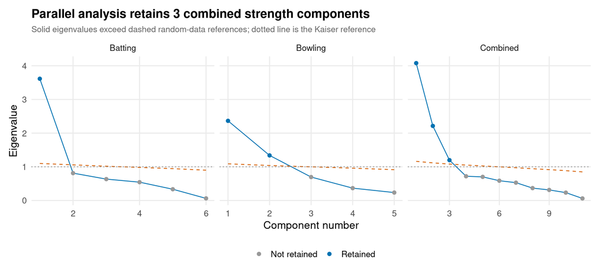

**How to read this:** Retained components explain more variation than the random-data reference.

**What it means:** Training data decide the dimension before any held-out transformation.

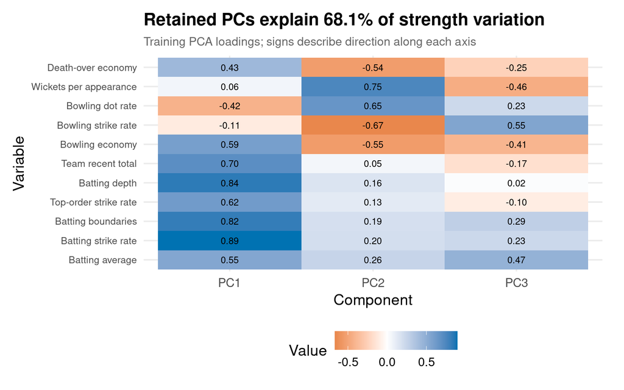

**How to read this:** Large absolute values identify the variables defining each component.

**What it means:** Components summarise shared variation, not necessarily predictive signal.

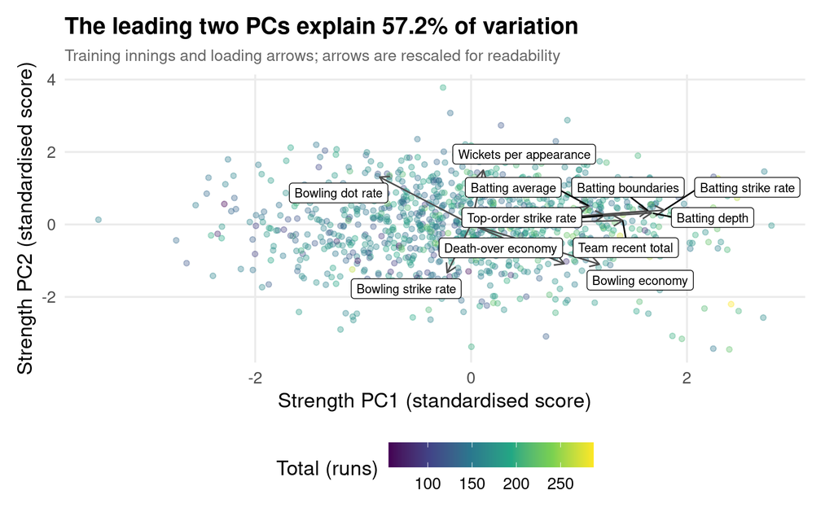

**How to read this:** Nearby arrows identify related features; score colour is descriptive only.

**What it means:** Outcome colour does not influence PCA fitting.

```r
read_result("dimension_checks") %>% select(block, variables, retained_pcs, retained_factors, pca_variance, min_uniqueness, boundary_warning) %>% knitr::kable(digits=3)
```

| block | variables | retained_pcs | retained_factors | pca_variance | min_uniqueness | boundary_warning |
| --- | --- | --- | --- | --- | --- | --- |
| Batting | 6 | 1 | 2 | 0.603 | -0.041 | TRUE |
| Bowling | 5 | 2 | 2 | 0.741 | -0.341 | TRUE |
| Combined | 11 | 3 | 3 | 0.681 | 0.010 | FALSE |

```r
read_result("dimension_names") %>% filter(kind == "PCA") %>% knitr::kable()
```

| kind | axis | strongest_feature | interpretation | block |
| --- | --- | --- | --- | --- |
| PCA | PC1 | bat_strike_rate | Batting pace and depth | Batting |
| PCA | PC1 | bowl_dot_pct | Bowling control and late-over pressure | Bowling |
| PCA | PC2 | bowl_strike_rate | Wicket-taking efficiency and mixed strength | Bowling |
| PCA | PC1 | bat_strike_rate | Batting pace and depth | Combined |
| PCA | PC2 | bowl_wickets_match | Bowling wicket threat | Combined |
| PCA | PC3 | bowl_strike_rate | Wicket-taking efficiency and mixed strength | Combined |

**How to read this:** component loadings define the axes; score weights calculate each match’s location. **What it means:** high explained input variance does not establish good score predictions.

## 4.5 Factor Analysis

The combined principal-axis solution retains 3 factors, with minimum uniqueness 0.010.

```r
show_figures(13:14)
```

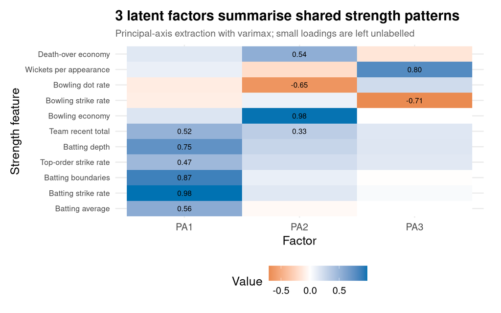

**How to read this:** Loadings connect observed measurements to estimated latent factors.

**What it means:** Factors are statistical interpretations rather than directly observed abilities.

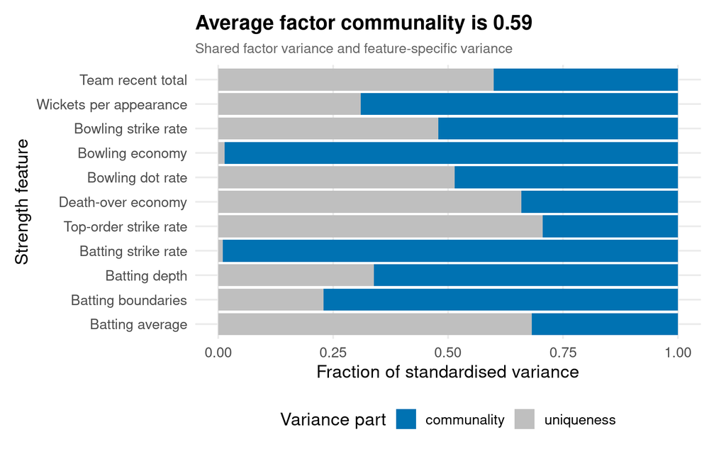

**How to read this:** Blue is the fraction explained by common factors; grey is uniqueness.

**What it means:** Low communality means the factor model represents that variable poorly.

```r
tab("communalities")
```

| variable | communality | uniqueness |
| --- | --- | --- |
| bat_average | 0.318 | 0.682 |
| bat_strike_rate | 0.990 | 0.010 |
| bat_boundary_pct | 0.771 | 0.229 |
| bat_top_order_sr | 0.294 | 0.706 |
| bat_depth | 0.661 | 0.339 |
| team_last10_total | 0.401 | 0.599 |
| bowl_economy | 0.986 | 0.014 |
| bowl_strike_rate | 0.521 | 0.479 |
| bowl_dot_pct | 0.486 | 0.514 |
| bowl_wickets_match | 0.690 | 0.310 |
| bowl_death_economy | 0.340 | 0.660 |

```r
tab("factor_correlations")
```

| factor1 | factor2 | correlation |
| --- | --- | --- |
| PA1 | PA1 | 1 |
| PA2 | PA1 | 0 |
| PA3 | PA1 | 0 |
| PA1 | PA2 | 0 |
| PA2 | PA2 | 1 |
| PA3 | PA2 | 0 |
| PA1 | PA3 | 0 |
| PA2 | PA3 | 0 |
| PA3 | PA3 | 1 |

The separate batting and bowling solutions have minimum uniqueness of -0.041 and -0.341. Their negative estimates are improper: those block-specific factors do not support valid variance decompositions. Package warnings are saved; no alternate extraction method is substituted. The proper combined solution is used for prediction.

**How to read this:** blue bars are common-factor variance and grey bars are uniqueness in the combined solution. **What it means:** latent-factor interpretations require checks, even when the same class procedure runs successfully.

## 4.6 PCA versus Factor Analysis and the prediction connection

Both score regressions predict the same validation innings using training-only transformations.

```r
show_figures(15)
```

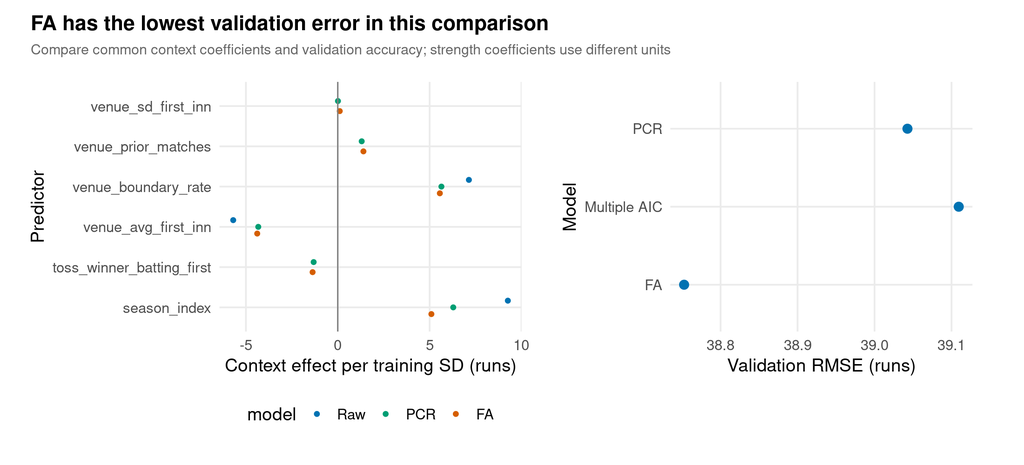

**How to read this:** Compare context effects across methods and RMSE on the same held-out season.

**What it means:** Reducing dimensions is useful only if it preserves relevant information.

```r
read_result("validation_metrics") %>% filter(model %in% c("Multiple AIC", "PCR", "FA")) %>% knitr::kable(digits=3)
```

| model | p | adj_r2 | rmse | mae | r2 |
| --- | --- | --- | --- | --- | --- |
| Multiple AIC | 6 | 0.105 | 39.109 | 30.915 | -0.071 |
| PCR | 9 | 0.096 | 39.043 | 30.796 | -0.067 |
| FA | 9 | 0.099 | 38.753 | 30.829 | -0.051 |

```r
tab("score_example_summary")
```

| method | match_id | actual | first_score | predicted |
| --- | --- | --- | --- | --- |
| PCR | 1473438 | 174 | 2.158 | 191.746 |
| FA | 1473438 | 174 | 1.381 | 190.723 |

For the saved validation example, each raw strength value is standardized using its training mean and SD, multiplied by a saved score weight, and summed. The regression then multiplies those scores and context values by fitted coefficients and adds its intercept. The learning guide gives the full numerical calculation.

**How to read this:** input variation, factor variance and prediction error answer different questions. **What it means:** PCA and FA create inputs for regression; they do not themselves predict cricket totals.

## 4.7 Cluster analysis

Silhouette selects 2 venue groups, with average-linkage hierarchy as the main comparison.

```r
show_figures(16:18)
```

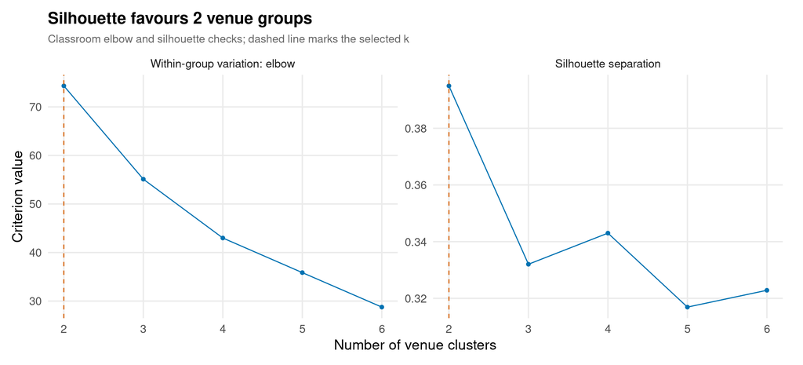

**How to read this:** Within-group variation falls as k grows; larger silhouette means better separation.

**What it means:** The recorded silhouette rule makes the choice reproducible.

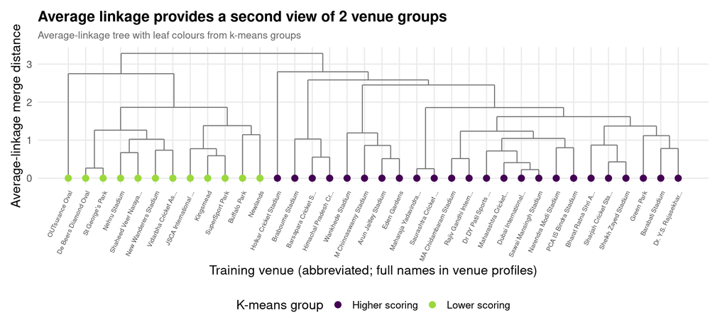

**How to read this:** Nearby venues merge earlier; leaf colours indicate the alternative grouping.

**What it means:** Membership tables compare the grouping methods without treating labels as ordered numbers.

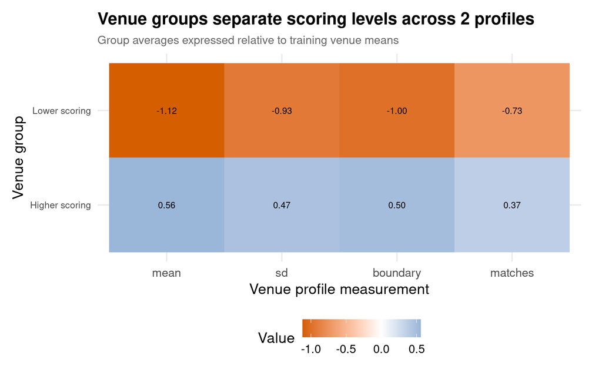

**How to read this:** Blue is above the training mean and orange below it.

**What it means:** Match-count differences also influence these historical groups.

```r
tab("cluster_summary")
```

| k | silhouette | main_linkage | random_starts |
| --- | --- | --- | --- |
| 2 | 0.395 | average | 25 |

```r
tab("cluster_membership_tables")
```

| linkage | kmeans | hierarchical | Freq |
| --- | --- | --- | --- |
| single | Higher scoring | 1 | 24 |
| single | Lower scoring | 1 | 11 |
| single | Higher scoring | 2 | 0 |
| single | Lower scoring | 2 | 1 |
| complete | Higher scoring | 1 | 24 |
| complete | Lower scoring | 1 | 0 |
| complete | Higher scoring | 2 | 0 |
| complete | Lower scoring | 2 | 12 |
| average | Higher scoring | 1 | 24 |
| average | Lower scoring | 1 | 0 |
| average | Higher scoring | 2 | 0 |
| average | Lower scoring | 2 | 12 |

**How to read this:** membership counts compare partitions; matching numeric labels are not required. **What it means:** venue group labels describe training profiles rather than permanent ground identities.

## 4.8 Outlier detection

333 training innings trigger at least one inspection rule.

```r
show_figures(19:21)
```

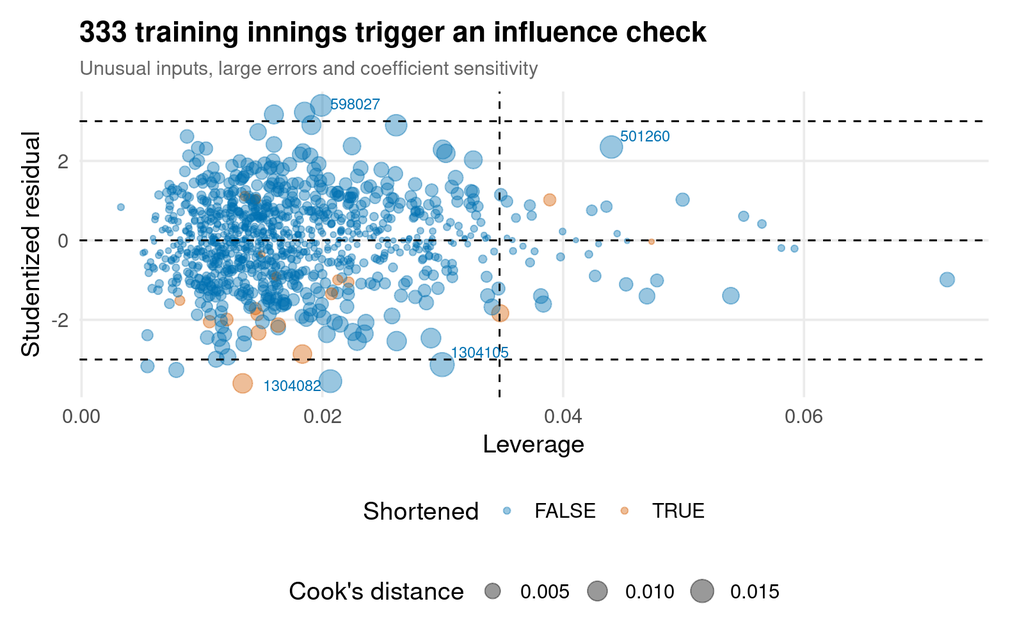

**How to read this:** Large bubbles affect coefficients; dashed lines mark inspection thresholds.

**What it means:** Statistical flags prompt explanation rather than automatic deletion.

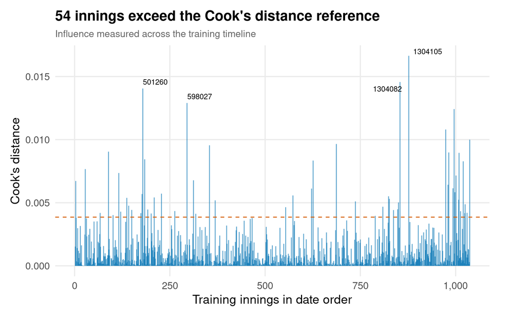

**How to read this:** Stems above the dashed line merit investigation.

**What it means:** A few influential innings can change estimated relationships.

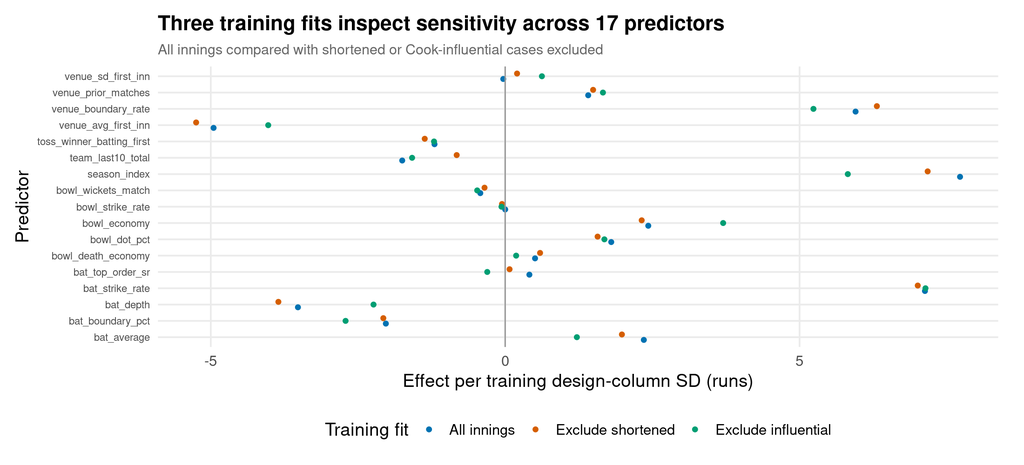

**How to read this:** Compare each coefficient across the three fits.

**What it means:** Sensitivity exclusions never remove assessment cases.

```r
tab("influence_thresholds")
```

| N | predictors | studentized_cutoff | leverage_cutoff | cooks_cutoff | dffits_cutoff | dfbetas_cutoff | mahalanobis_cutoff |
| --- | --- | --- | --- | --- | --- | --- | --- |
| 1037 | 17 | 3 | 0.035 | 0.004 | 0.263 | 0.062 | 33.409 |

```r
read_result("flagged_innings") %>% arrange(desc(cooks)) %>% select(match_id, venue, season, first_innings_total, curtailed, explanation) %>% head(8) %>% knitr::kable()
```

| match_id | venue | season | first_innings_total | curtailed | explanation |
| --- | --- | --- | --- | --- | --- |
| 1304105 | Wankhede Stadium | 2022 | 97 | FALSE | Much lower total than expected: inspect a batting collapse or interruption. |
| 1304082 | Brabourne Stadium | 2022 | 68 | FALSE | Much lower total than expected: inspect a batting collapse or interruption. |
| 501260 | Himachal Pradesh Cricket Association Stadium | 2011 | 232 | FALSE | Unusual historical feature combination, often a venue or roster cold start. |
| 598027 | M Chinnaswamy Stadium | 2013 | 263 | FALSE | Much higher total than the pre-match model expected: inspect exceptional scoring. |
| 1426268 | M Chinnaswamy Stadium | 2024 | 287 | FALSE | Coefficient sensitivity merits inspection; the statistical flag alone is not grounds for deletion. |
| 1422126 | Rajiv Gandhi International Stadium | 2024 | 277 | FALSE | Much higher total than the pre-match model expected: inspect exceptional scoring. |
| 1426312 | MA Chidambaram Stadium | 2024 | 113 | FALSE | Coefficient sensitivity merits inspection; the statistical flag alone is not grounds for deletion. |
| 1178424 | M Chinnaswamy Stadium | 2019 | 62 | TRUE | Fewer legal balls without being all out: shortened exposure may explain the low score. |

```r
read_result("validation_metrics") %>% filter(model %in% c("Exclude curtailed", "Exclude influential")) %>% knitr::kable(digits=3)
```

| model | p | adj_r2 | rmse | mae | r2 |
| --- | --- | --- | --- | --- | --- |
| Exclude curtailed | 17 | 0.102 | 38.903 | 30.877 | -0.059 |
| Exclude influential | 17 | 0.118 | 38.577 | 30.713 | -0.042 |

**How to read this:** case-removal fits alter training observations, while assessment cases remain unchanged. **What it means:** valid extremes can affect coefficients, and removal can also narrow fitted uncertainty.

## 4.9 Heteroscedasticity

Training residual variance differs across the saved venue groups; inverse variances provide WLS weights.

```r
show_figures(22:25)
```

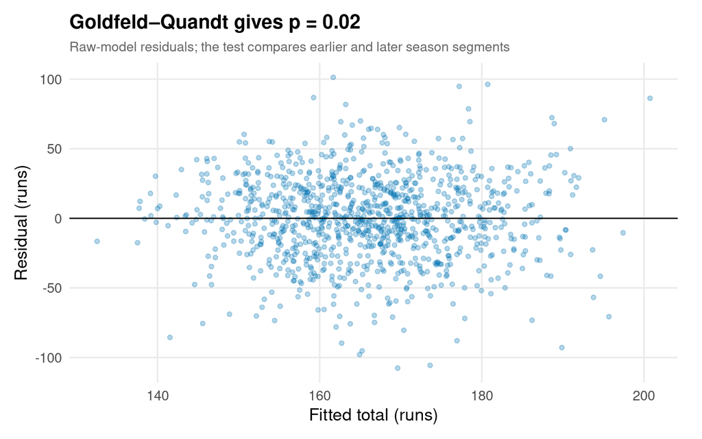

**How to read this:** Look for changing vertical spread around zero.

**What it means:** A variance test does not establish which remedy predicts better.

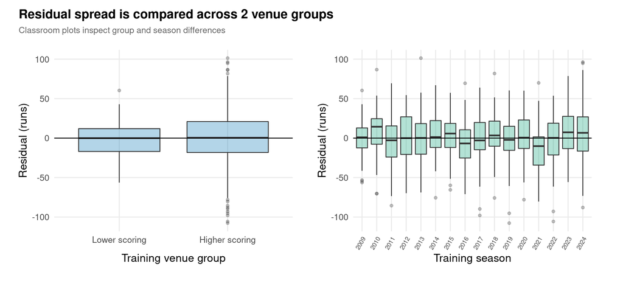

**How to read this:** Compare box heights rather than only their centres.

**What it means:** Group residual variances determine the WLS weights.

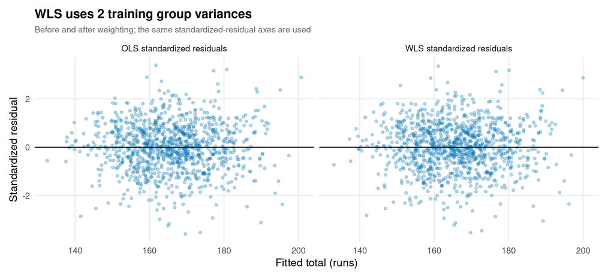

**How to read this:** Compare spread within each panel.

**What it means:** Weighting changes the fit; it does not ensure equal remaining variance.

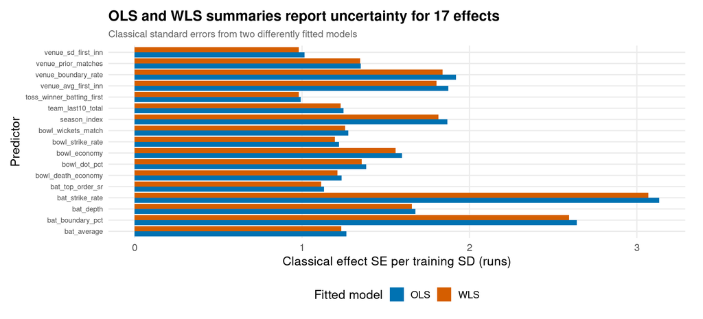

**How to read this:** Longer bars mean larger model-based coefficient uncertainty.

**What it means:** These estimates rely on each fitted model’s variance assumptions.

```r
tab("heteroscedasticity_tests")
```

| model | test | statistic | p_value |
| --- | --- | --- | --- |
| Raw | Goldfeld–Quandt | 1.203 | 0.020 |
| Log total | Goldfeld–Quandt | 1.053 | 0.282 |

```r
tab("venue_variance")
```

| venue_cluster | N | variance | predicted_sd | used_pooled_fallback |
| --- | --- | --- | --- | --- |
| Lower scoring | 78 | 570.796 | 23.891 | FALSE |
| Higher scoring | 959 | 928.331 | 30.469 | FALSE |

```r
read_result("validation_metrics") %>% filter(model %in% c("Log total", "WLS")) %>% knitr::kable(digits=3)
```

| model | p | adj_r2 | rmse | mae | r2 |
| --- | --- | --- | --- | --- | --- |
| Log total | 17 | 0.089 | 39.100 | 31.343 | -0.070 |
| WLS | 17 | 0.107 | 38.782 | 30.900 | -0.053 |

**How to read this:** Goldfeld–Quandt compares variance between earlier and later season segments; group variances answer a different question. **What it means:** diagnose the pattern and evaluate the remedy separately. Classical standard errors still rely on their model’s assumptions.

## 4.10 Final comparison and revised test evaluation

Validation selects **Exclude influential**, fitted on 983 training innings with 17 predictors: test RMSE **41.0 runs**, MAE **32.1 runs**, and predictive R-squared **0.006**.

```r
show_figures(26:28)
```

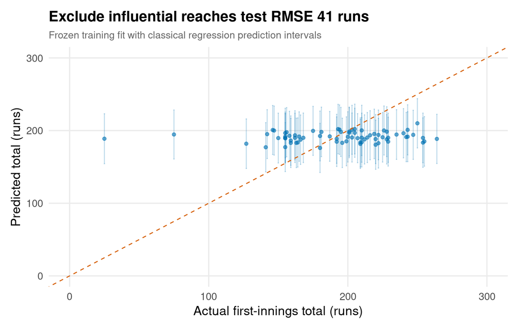

**How to read this:** Points near equality predict well; bars describe individual-score uncertainty.

**What it means:** Observed interval coverage is 58.1%; model assumptions and season changes affect coverage.

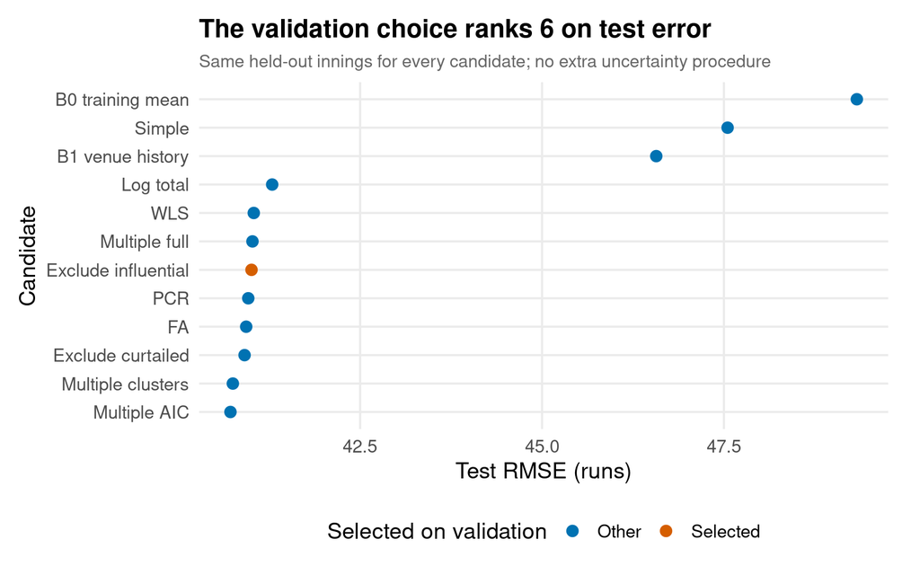

**How to read this:** Lower RMSE means smaller squared prediction errors.

**What it means:** Test ranks describe results without changing the selected model.

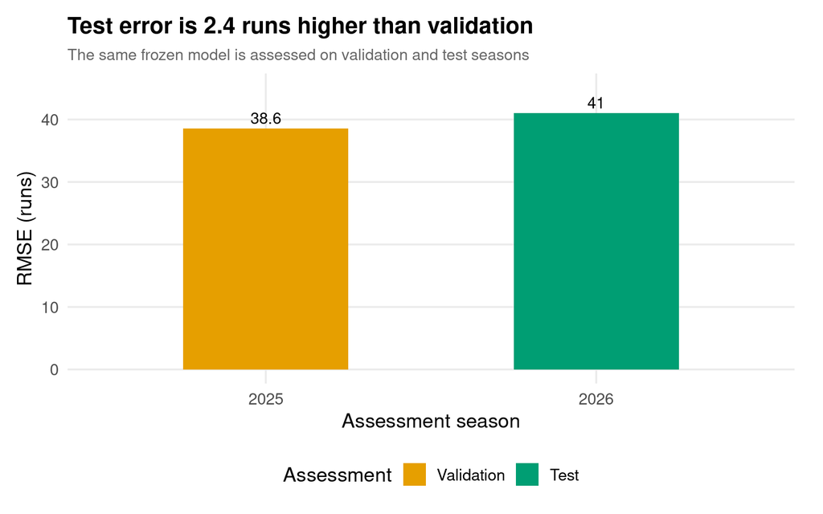

**How to read this:** Bar heights show error with a common zero origin.

**What it means:** Season changes can alter forecasting performance.

```r
tab("test_metrics")
```

| model | rmse | mae | r2 | p | adj_r2 | validation_rmse | test_rank |
| --- | --- | --- | --- | --- | --- | --- | --- |
| B0 training mean | 49.327 | 39.972 | -0.438 | 0 | NA | 44.264 | 12 |
| B1 venue history | 46.570 | 38.178 | -0.282 | 0 | NA | 43.034 | 10 |
| Exclude curtailed | 40.911 | 31.868 | 0.011 | 17 | 0.102 | 38.903 | 3 |
| Exclude influential | 41.007 | 32.084 | 0.006 | 17 | 0.118 | 38.577 | 6 |
| FA | 40.934 | 32.094 | 0.010 | 9 | 0.099 | 38.753 | 4 |
| Log total | 41.291 | 32.391 | -0.008 | 17 | 0.089 | 39.100 | 9 |
| Multiple AIC | 40.717 | 31.870 | 0.020 | 6 | 0.105 | 39.109 | 1 |
| Multiple clusters | 40.750 | 32.015 | 0.019 | 7 | 0.105 | 39.113 | 2 |
| Multiple full | 41.020 | 31.951 | 0.006 | 17 | 0.103 | 38.786 | 7 |
| PCR | 40.962 | 32.065 | 0.008 | 9 | 0.096 | 39.043 | 5 |
| Simple | 47.551 | 38.815 | -0.336 | 1 | 0.007 | 43.077 | 11 |
| WLS | 41.038 | 31.929 | 0.005 | 17 | 0.107 | 38.782 | 8 |

```r
tab("interval_summary")
```

| model | nominal_coverage | empirical_coverage | mean_width | method |
| --- | --- | --- | --- | --- |
| Exclude influential | 0.8 | 0.581 | 68.036 | classical regression prediction interval |

**How to read this:** the chosen model remains the validation winner even if another candidate has smaller test error. **What it means:** nominal 80% intervals cover only 58.1% of test scores. These intervals under-cover substantially; individual-score uncertainty is larger than the selected model’s classical calculation suggests.

# 5 Conclusion

The research questions are answered by the saved comparison:

- **Baselines:** the selected model beats both baselines. Its RMSE is 41.0, compared with 49.3 for the training mean and 46.6 for venue history.
- **Additional inputs:** compare the simple and multiple candidates on the same later innings. Coefficients remain conditional associations; selection and correlated histories limit interpretation.
- **Compression:** PCA retains 3 components and proper combined FA retains 3 factors. Their forecasts are evaluated separately from explained input variation. The separate FA blocks are improper and are reported as limitations.
- **Sensitivity and variance:** flagged-case exclusions, log response and WLS give explicit alternatives. The validation-selected case-removal fit has substantial classical interval under-coverage on test.

Predictive R-squared of 0.006 shows that most individual-score variation remains unexplained, even when the historical baselines are beaten. The test-season mean is unavailable beforehand, but it is the reference used in predictive R-squared. Much of the benefit may therefore concern adapting the scoring level rather than identifying which particular innings will be high or low.

Limitations include shortened matches, sparse history, inferred batting roles, unknown later substitutions, combined venue identities, model-selection uncertainty and changing scoring conditions. Case-removal fitting narrows the training distribution, and this may contribute to inadequate interval width. This is a syllabus-aligned revision of an already evaluated dataset, not a new untouched test experiment. Future evaluation should use a genuinely later season and independently verified pre-match information.

The selected regression predicts actual first-innings totals with test RMSE of 41.0 runs. Its interval under-coverage limits the precision that can be claimed. The reproducible project connects the class methods to historical inputs, fitted scores and honest prediction checks.